# Viewing Space (study1adults)

Adam Stone, PhD

10-05-2017

# Get Data

```r
# Import packages we'll need.
library(tidyverse)
library(stringr)
library(lme4)
library(lmerTest)
library(png)
library(grid)
# Gather up the files
files <- list.files(pattern = "\\.csv",path="rawdata")
files <- str_c("rawdata/",files)
rawdata <- do.call("rbind", lapply(files, read_csv))
# Clean Up
rawdataoriginal <- rawdata
rawdata <- rawdataoriginal
rawdata <- rawdata %>%
  rename(participant = ParticipantName,
         group = "[Group]Value",
         language = "[Language]Value",
         media = MediaName,
         x = "GazePointX (MCSpx)",
         y = "GazePointY (MCSpx)",
         gazeindex = GazePointIndex) %>%
  select(participant,group,language,media,x,y,gazeindex) %>%
  add_column(story=NA,direction=NA,maingroup=NA) %>%
  mutate(story = case_when(
    str_detect(media,"bears") ~ "bears",
    str_detect(media,"cinderella") ~ "cinderella",
    str_detect(media,"midas") ~ "midas",
    str_detect(media,"redridinghood") ~ "redridinghood")) %>%
  mutate(direction = case_when(
    str_detect(media,"FW") ~ "forward",
    str_detect(media,"ER") ~ "reversed")) %>%
  mutate(media = str_c(story,direction, sep="_")) %>%
  mutate(language = case_when(
    str_detect(language,"EarlyASL") ~ "Early",
    str_detect(language,"LateASL") ~ "Late",
    str_detect(language,"NoviceASL_Trained") ~ "Trained",
    str_detect(language,"NoviceASL") ~ "Novice")) %>%
  mutate(maingroup = str_c(group,language, sep="")) %>%
  filter(!is.na(maingroup))
glimpse(rawdata)
```

```
Observations: 809,920
Variables: 10
$ participant <chr> "Adam", "Adam", "Adam", "Adam", "Adam", "Adam", "Adam", "Adam", "Adam", "Adam", "...
$ group       <chr> "Deaf", "Deaf", "Deaf", "Deaf", "Deaf", "Deaf", "Deaf", "Deaf", "Deaf", "Deaf", "...
$ language    <chr> "Early", "Early", "Early", "Early", "Early", "Early", "Early", "Early", "Early", ...
$ media       <chr> "bears_forward", "bears_forward", "bears_forward", "bears_forward", "bears_forwar...
$ x           <int> 702, 703, 700, 695, 693, 704, 709, 708, 712, 717, 712, 709, 707, 697, 698, 704, 6...
$ y           <int> 493, 493, 495, 498, 503, 514, 513, 502, 495, 501, 506, 507, 510, 517, 511, 507, 5...
$ gazeindex   <int> 1, 2, 3, 4, 5, 6, 7, 8, 9, 10, 11, 12, 13, 14, 15, 16, 17, 18, 19, 20, 21, 22, 23...
$ story       <chr> "bears", "bears", "bears", "bears", "bears", "bears", "bears", "bears", "bears", ...
$ direction   <chr> "forward", "forward", "forward", "forward", "forward", "forward", "forward", "for...
$ maingroup   <chr> "DeafEarly", "DeafEarly", "DeafEarly", "DeafEarly", "DeafEarly", "DeafEarly", "De...
```

Now that it’s in the right format…it’s easy to get what we need! :-D

# Analysis

First, let’s trim each participant’s data, getting rid of the first 30 samples (0.5 secs). Then we’ll get the the mean x and y coordinate for each story for each participant.

```r
rawdata <- rawdata %>%
  arrange(participant,media,gazeindex) %>%
  group_by(participant,media) %>%
  slice(30:n())
means <- rawdata %>%
  group_by(participant,media) %>%
  dplyr::summarize(x = mean(x,na.rm=TRUE),
            y = mean(y,na.rm=TRUE))
head(means,10)
```

| participant | media | x | y |
| --- | --- | --- | --- |
| Adam | bears_forward | 684.7927 | 388.0363 |
| Adam | cinderella_reversed | 693.0038 | 374.5328 |
| Adam | midas_forward | 687.6085 | 389.2098 |
| Adam | redridinghood_reversed | 696.7134 | 381.1237 |
| alicia 2 | bears_reversed | 678.2617 | 436.0024 |
| alicia 2 | cinderella_forward | 688.5115 | 409.0559 |
| alicia 2 | midas_reversed | 672.8772 | 393.5976 |
| alicia 2 | redridinghood_forward | 703.5676 | 353.4820 |
| Alicia Deaf | midas_reversed | 688.1792 | 395.6458 |
| Alicia Deaf | redridinghood_forward | 701.0710 | 404.0687 |

And I can get x or y plots of one participant across 4 stories. Let’s do Adam (me?). We’ll set the x and y limits to the whole width of the Tobii monitor (1600x1200). But because Tobii considers (0,0) to be the upper left corner (and not the bottom left corner), we also need to flip the y axis.

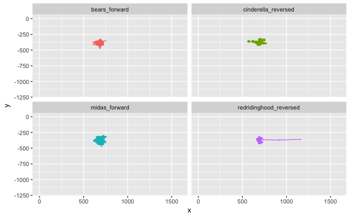

```r
adam <- filter(rawdata,participant=="Adam") %>% mutate(y = y*-1)
ggplot(adam,aes(x=x,y=y,color=media)) + geom_point(size=0.1) + geom_path() + facet_wrap("media",ncol=2,nrow=2) + guides(color="none") + scale_x_continuous(limit=c(0,1600)) + scale_y_continuous(limit=c(-1200,0))
```

Cool, yeah?

Let’s try this again but let the x and y limits match the data. That will “zoom” in. We’ll also get rid of that weird right-side outlier in RRH. Neatooooo.

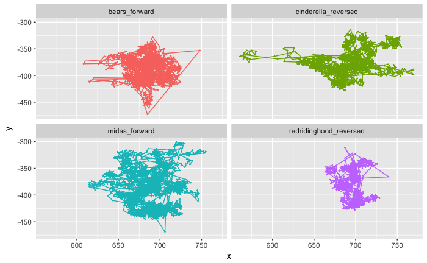

```r
adam <- filter(adam,x<800)
ggplot(adam,aes(x=x,y=y,color=media)) + geom_point(size=0.1) + geom_path() + facet_wrap("media",ncol=2,nrow=2) + guides(color="none")
```

# IQR

Now let’s get the middle 50% (aka the IQR) of x and y for each participant’s story. That should also take care of further weird outliers. And we are defining “viewing space” as the IQR of the x and y axis.

```r
iqr <- rawdata %>%
  group_by(participant,media) %>%
  dplyr::summarize(xIQR = IQR(x,na.rm=TRUE),
                   yIQR = IQR(y,na.rm=TRUE),
                   xmed = median(x, na.rm=TRUE),
                   ymed = median(y, na.rm=TRUE))
head(iqr,10)
```

| participant | media | xIQR | yIQR | xmed | ymed |
| --- | --- | --- | --- | --- | --- |
| Adam | bears_forward | 20.00 | 32.00 | 685 | 388.0 |
| Adam | cinderella_reversed | 34.00 | 33.00 | 693 | 376.0 |
| Adam | midas_forward | 28.00 | 58.00 | 690 | 389.0 |
| Adam | redridinghood_reversed | 14.00 | 47.00 | 698 | 382.0 |
| alicia 2 | bears_reversed | 44.75 | 30.00 | 685 | 411.0 |
| alicia 2 | cinderella_forward | 37.00 | 44.00 | 699 | 415.0 |
| alicia 2 | midas_reversed | 46.00 | 45.00 | 684 | 385.0 |
| alicia 2 | redridinghood_forward | 28.00 | 33.75 | 692 | 348.5 |
| Alicia Deaf | midas_reversed | 27.00 | 20.00 | 682 | 389.0 |
| Alicia Deaf | redridinghood_forward | 23.00 | 35.00 | 704 | 395.0 |

And check out the histograms:

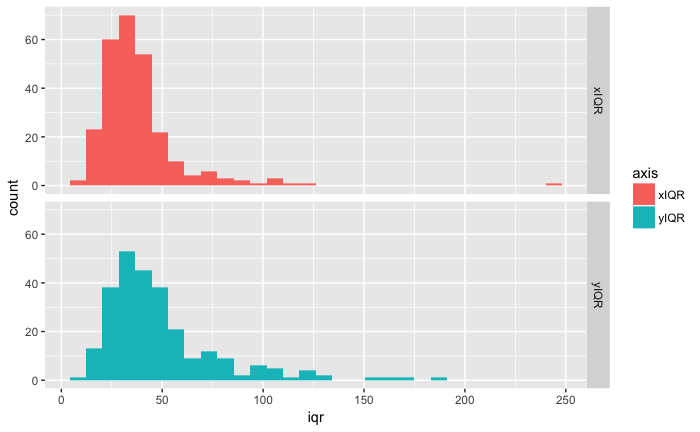

```r
iqr %>%
  gather(axis,iqr,xIQR:yIQR) %>%
  ggplot(aes(x=iqr,fill=axis)) + geom_histogram() + facet_grid(axis~.)
```

There’s one weird outlier for xIQR. That’s Rebecca. Let’s look at her data.

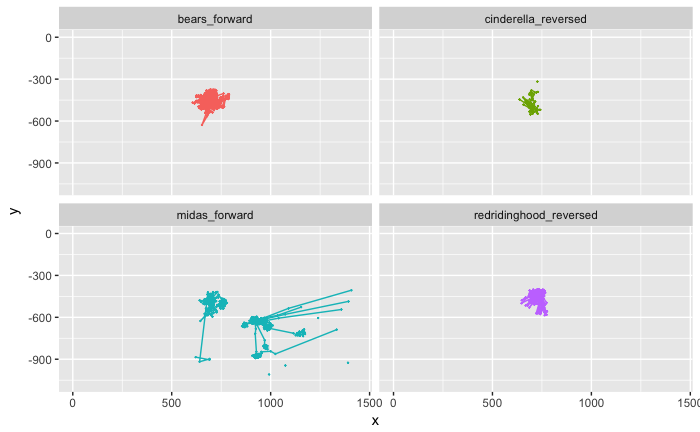

```r
rebecca <- filter(rawdata,participant=="Rebecca") %>% mutate(y = y*-1)
ggplot(rebecca,aes(x=x,y=y,color=media)) + geom_point(size=0.1) + geom_path() + facet_wrap("media",ncol=2,nrow=2) + guides(color="none") + xlim(0,1440) + ylim(-1080,0)
```

So we’ll remove Rebecca’s midas_forward story. Next, check the medians.

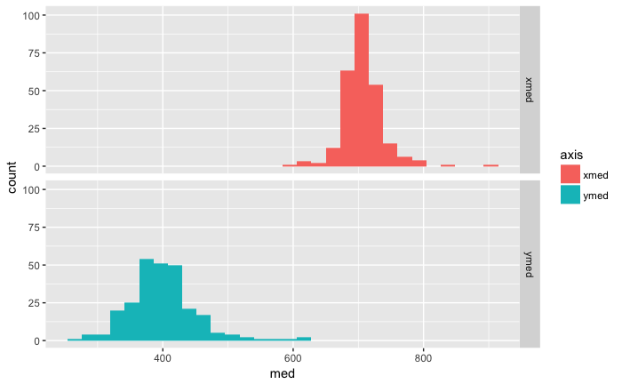

```r
iqr %>%
  gather(axis,med,xmed:ymed) %>%
  ggplot(aes(x=med,fill=axis)) + geom_histogram() + facet_grid(axis~.)
```

Looks great! But it also looks pretty interesting doesn’t it…Y median has a wider spread than X median. That would make sense.

Now we’re ready to do stats based on group, direction, etc.

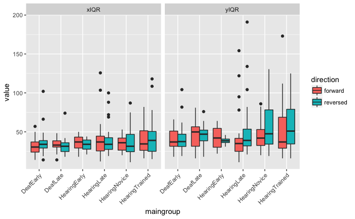

```r
rbc <- tribble(~participant, ~media, "Rebecca","midas_forward")
iqr <- iqr %>%
  ungroup() %>%
  anti_join(rbc, by=c("participant","media")) # for some reason filter wouldn't work
subjectinfo <- rawdata %>%
  select(participant,maingroup,group,language,media,story,direction) %>%
  distinct() %>%
  filter(!is.na(participant))
iqr <- iqr %>%
  left_join(subjectinfo,by=c("participant","media")) %>%
  filter(!is.na(maingroup))
iqr.gather <- iqr %>% gather(axis,value,xIQR:ymed)
iqr.iqr <- filter(iqr.gather,axis=="xIQR" | axis=="yIQR")
iqr.med <- filter(iqr.gather,axis=="xmed" | axis=="ymed")
ggplot(iqr.iqr,aes(x=maingroup,y=value,fill=direction)) +
  geom_boxplot() + theme(axis.text.x=element_text(angle=45,hjust=1)) +
  facet_grid(.~axis)
```

And the median x and y position (this assumes all calibrations are correct):

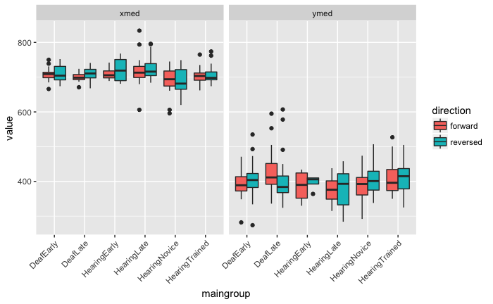

```r
ggplot(iqr.med,aes(x=maingroup,y=value,fill=direction)) +
  geom_boxplot() + theme(axis.text.x=element_text(angle=45,hjust=1)) +
  facet_grid(.~axis)
```

First, does reversal have an effect on X IQR? We have random intercepts for each participant and media, and a random slope adjustment for reversed for each participant.

```r
xiqr.reversal <- lmer(xIQR ~ direction + (direction|participant) + (1|media), data = iqr)
summary(xiqr.reversal)$coefficients
```

```
                   Estimate Std. Error       df   t value     Pr(>|t|)
(Intercept)       36.658318   4.353165 5.906561 8.4210733 0.0001661414
directionreversed  1.912058   6.019849 5.389901 0.3176256 0.7627088522
```

Welp. No. Y IQR?

```r
yiqr.reversal <- lmer(yIQR ~ direction + (direction|participant) + (1|media), data = iqr)
summary(yiqr.reversal)$coefficients
```

```
                   Estimate Std. Error       df    t value     Pr(>|t|)
(Intercept)       45.757853   4.157688 6.949055 11.0055997 1.195784e-05
directionreversed  4.719519   5.245332 4.318736  0.8997561 4.155988e-01
```

No effect here either. Let’s try adding maingroups. X IQR first.

```r
xiqr.group <- lmer(xIQR ~ direction * maingroup + (direction|participant) + (1|media), data = iqr)
summary(xiqr.group)$coefficients
```

```
                                           Estimate Std. Error         df    t value     Pr(>|t|)
(Intercept)                               32.466356   5.067277   9.219453  6.4070614 0.0001116686
directionreversed                          5.883363   6.826873   7.584826  0.8617947 0.4152132835
maingroupDeafLate                         -1.537986   4.946390  75.565711 -0.3109310 0.7567091452
maingroupHearingEarly                      3.033644   8.638151  68.852824  0.3511913 0.7265171890
maingroupHearingLate                       9.272544   4.153781  71.594867  2.2323141 0.0287234102
maingroupHearingNovice                     4.130657   4.433650  70.106043  0.9316605 0.3547093793
maingroupHearingTrained                    8.399715   4.134045  70.594133  2.0318395 0.0459347591
directionreversed:maingroupDeafLate       -6.382112   5.837424 102.756967 -1.0933097 0.2768142707
directionreversed:maingroupHearingEarly   -8.133363   9.942371  98.135777 -0.8180507 0.4153101295
directionreversed:maingroupHearingLate    -7.871281   4.820132 102.523572 -1.6330012 0.1055362967
directionreversed:maingroupHearingNovice  -4.285788   5.128440 100.377995 -0.8356903 0.4053139566
directionreversed:maingroupHearingTrained -2.749306   4.813129 101.888829 -0.5712097 0.5691153636
```

This means there is a significant difference of DeafEarly vs. HearingLate and HearingTrained on xIQR, but in the forward condition only. Basically, those two groups have a “wider” viewing space than other groups.

```r
yiqr.group <- lmer(yIQR ~ direction * maingroup + (direction|participant) + (1|media), data = iqr)
summary(yiqr.group)$coefficients
```

```
                                            Estimate Std. Error         df     t value     Pr(>|t|)
(Intercept)                               41.3149410   5.849687  25.104361  7.06276111 2.057123e-07
directionreversed                          0.6756862   6.370464   9.226171  0.10606547 9.178008e-01
maingroupDeafLate                          3.8111456   8.747145  67.708251  0.43570169 6.644391e-01
maingroupHearingEarly                      1.2475590  15.520700  60.923060  0.08038033 9.361982e-01
maingroupHearingLate                       2.7405081   7.432841  62.927907  0.36870267 7.135869e-01
maingroupHearingNovice                     6.4602450   7.950552  61.866761  0.81255305 4.195902e-01
maingroupHearingTrained                   11.2922019   7.405277  62.286455  1.52488579 1.323494e-01
directionreversed:maingroupDeafLate       -3.7311262   8.087989 138.085064 -0.46131693 6.452971e-01
directionreversed:maingroupHearingEarly   -4.7381862  13.774486 133.134441 -0.34398280 7.314019e-01
directionreversed:maingroupHearingLate     6.5001341   6.692006 136.966279  0.97132818 3.330971e-01
directionreversed:maingroupHearingNovice  10.8034113   7.112659 135.129358  1.51889903 1.311242e-01
directionreversed:maingroupHearingTrained  7.4259316   6.679035 136.371205  1.11182696 2.681688e-01
```

# Viewing Space Charts

I want to learn how to make rectangle plots so here we go. Using each participant’s four x and y medians and 4 x and y IQRs (one set for each story, for 4 stories). So I can get the logic and code down. Let’s assume all calibrations were correct. Here’s the chart for the whole media size of 1440x1080 (as reported in Tobii).

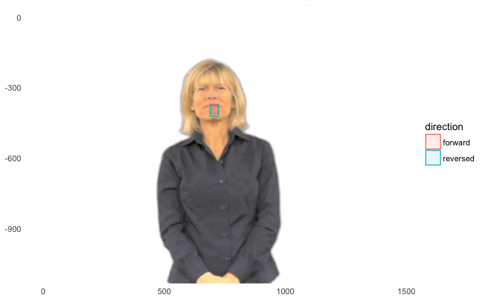

```r
# In this order, we'll get a grand median by taking a participant's median across their 4 stories, than the median for forward and reverse across all participants.
medians <- iqr %>%
  group_by(participant,direction) %>%
  dplyr::summarize(xIQR = median(xIQR,na.rm=TRUE),
                   yIQR = median(yIQR,na.rm=TRUE),
                   xmed = median(xmed,na.rm=TRUE),
                   ymed = median(ymed,na.rm=TRUE)) %>%
  group_by(direction) %>%
  dplyr::summarize(xIQR = median(xIQR,na.rm=TRUE),
                   yIQR = median(yIQR,na.rm=TRUE),
                   x = median(xmed,na.rm=TRUE),
                   y = median(ymed,na.rm=TRUE))
medians <- medians %>%
  mutate(y = y*-1,
         xmin = x-(xIQR/2),
         xmax = x+(xIQR/2),
         ymin = y-(yIQR/2),
         ymax = y+(yIQR/2))
img <- readPNG("cindy.png")
g <- rasterGrob(img, interpolate=TRUE, width=unit(1,"npc"), height=unit(1,"npc"))
ggplot(medians, aes(fill=direction,color=direction)) +
  annotation_custom(g, xmin=-Inf, xmax=Inf, ymin=-Inf, ymax=Inf) +
  geom_rect(aes(xmin=xmin,ymin=ymin,xmax=xmax,ymax=ymax),alpha=.1) +
  theme_minimal() + xlim(0,1440) + ylim(-1080,0)
```

```r
# ggplot(iqr.global, aes(fill=direction,color=direction)) +
#   annotation_custom(g, xmin=-Inf, xmax=Inf, ymin=-Inf, ymax=Inf) +
#   geom_rect(aes(xmin=xmin,ymin=ymin,xmax=xmax,ymax=ymax),alpha=.1) +
#   theme_minimal() + xlim(0,1440) + ylim(-1080,0) +
#   geom_hline(yintercept=-1080+885) +
#   geom_hline(yintercept=-1080+525) +
#   annotate(geom="text", x = 300, y = -1080+555, label = "upper shoulder point") +
#   annotate(geom="point", x = 535, y = -1080+525) +
#   annotate(geom="text", x = 535, y = -1080+910, label = "height line") +
#   annotate(geom="rect", xmin = 535, xmax = 535+365, ymin = -525-551, ymax = -1080+525, fill="maroon", color="black", alpha=0.5) +
#   annotate(geom="text", x = 700, y = -900, label = "torso")
```

Yayyy! It worked! A bit hard to see! Let’s zoom in.

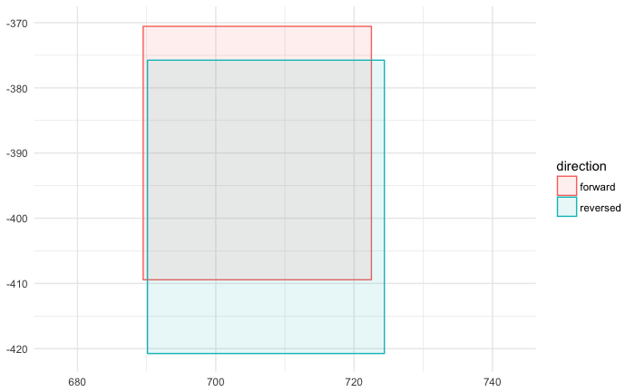

```r
# ggplot(iqr.global, aes(fill=direction,color=direction)) +
#   annotation_custom(g, xmin=0, xmax=1440, ymin=-1080, ymax=0) +
#   geom_rect(aes(xmin=xmin,ymin=ymin,xmax=xmax,ymax=ymax),alpha=.1) +
#   theme_minimal() + xlim(600,800) + ylim(-500,-300)
ggplot(medians, aes(fill=direction,color=direction)) +
  geom_rect(aes(xmin=xmin,ymin=ymin,xmax=xmax,ymax=ymax),alpha=.1) +
  theme_minimal() + xlim(677,743) + ylim(-421,-370)
```

```r
#ggplot(iqr.global, aes(fill=direction,color=direction)) +
#  geom_rect(aes(xmin=xmin,ymin=ymin,xmax=xmax,ymax=ymax),alpha=.1)
```

I have to figure out how to get Cindy to zoom in - or crop a zoomed in version of Cindy manually and use that.

# Viewing Space Charts for Individuals

Now let’s see the variation in viewing spaces for all our individuals. Should be fun.

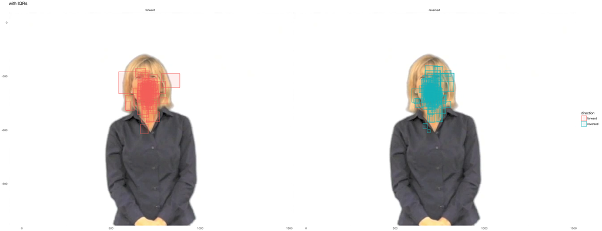

# Standard Deviations?

Let’s try using standard deviations instead.

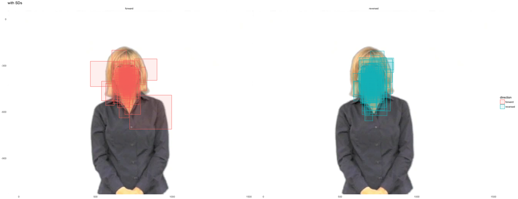